# Week 6: Graphs

TOC

- What are graphs
- Categorizing graphs
- Examples of hidden graphs
- What you can do with graphs
- BFS
- Djikstra
- Dynamic programming

# What are graphs

What are graphs?

- A collection of nodes and a collection of edges between nodes

What are trees? (Review)

- Finite recursive data structures
- Directed acyclic graphs
- Each node has at most one parent

So, all trees are graphs, not all graphs are trees

- So, graph algorithms will work with trees, tree algorithms might not work with all graphs
- Have we encountered any other graphs?
- Yes! Linked lists

So what are graphs?

- Collections of nodes
- And a collection of edges between nodes

# Categorizing graphs

What can vary? Edges

- The edges can be directed or undirected
- Directed means an edge is from one node to another
- Undirected means that there is no distinction, and an edge from X->Y implies an edge from Y->X
- Edges can optionally have weights or other info attached to them

What can vary? Nodes

- Just like with trees, we can attach whatever information we want to nodes
- E.g. a number, or a color (red/black), etc.

What can vary? Additional restrictions placed on the structure of the graph

- No cycles
- No negative-weight cycles
- Fully connected

# Examples of graphs

Graph examples: Undirected graph

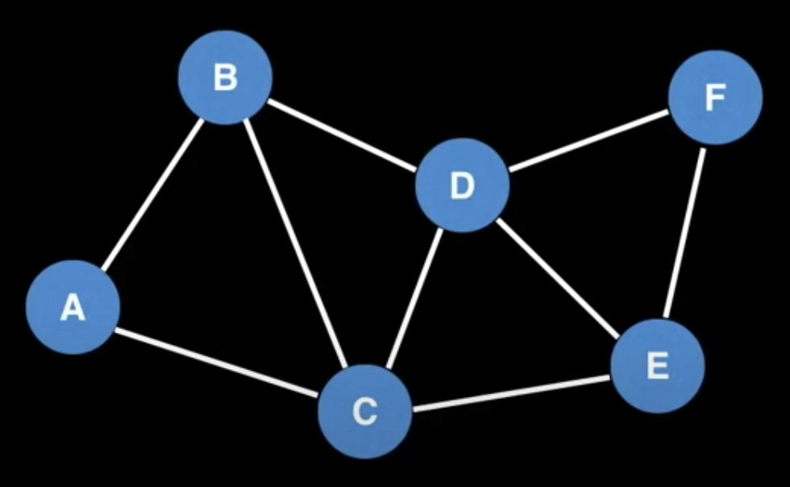

Graph examples: Directed graph

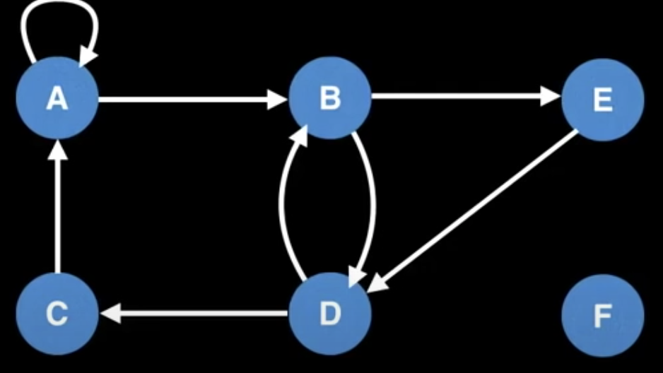

Chess set: neighbors

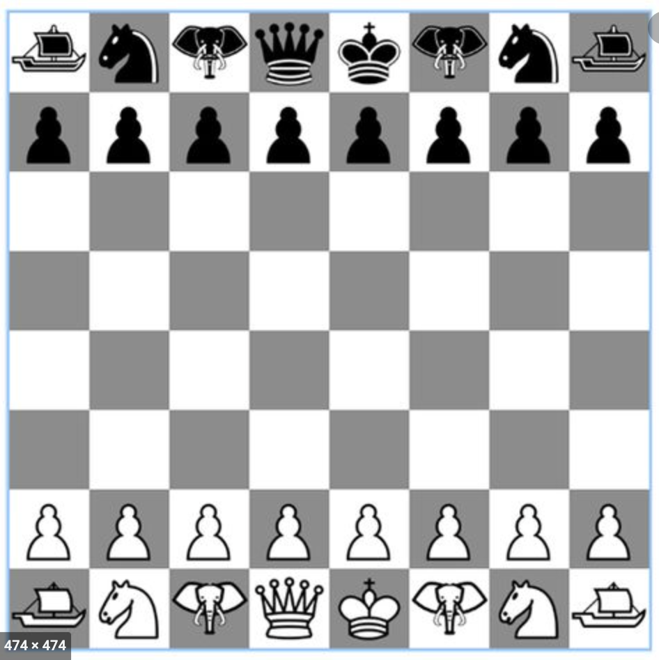

Chess set: moves

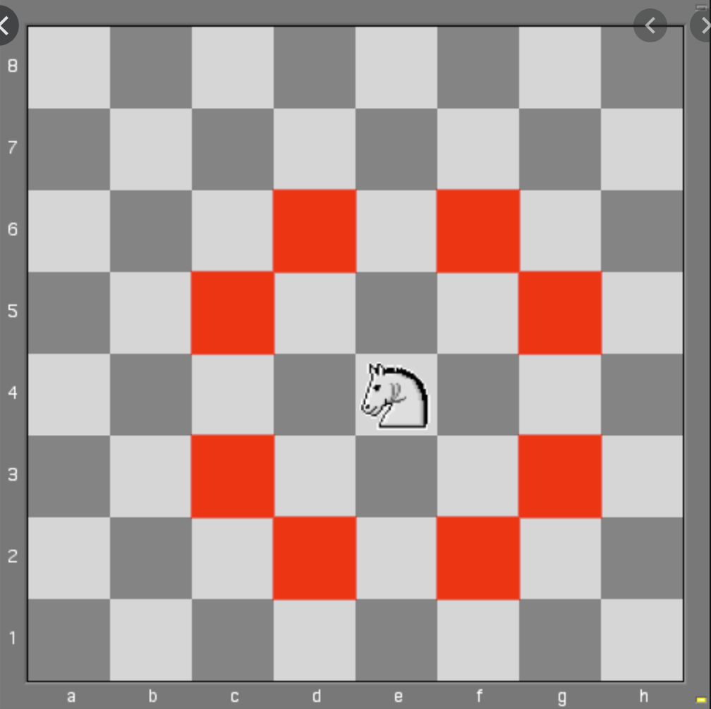

Grid of water and islands

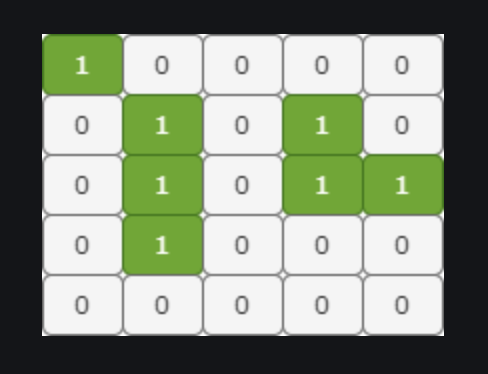

Class dependencies

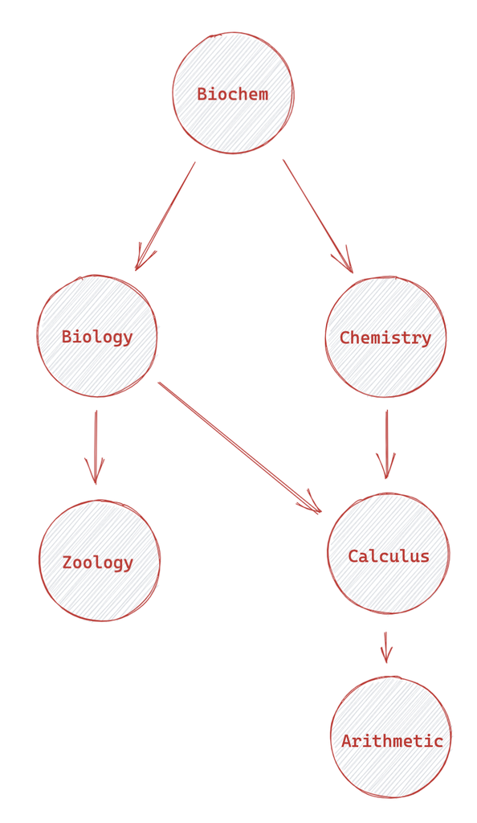

Dependencies: 2

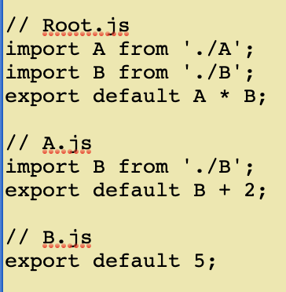

Dependencies: 3

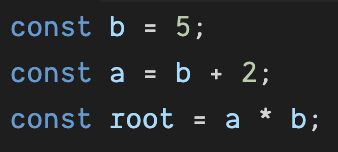

Exchange rates

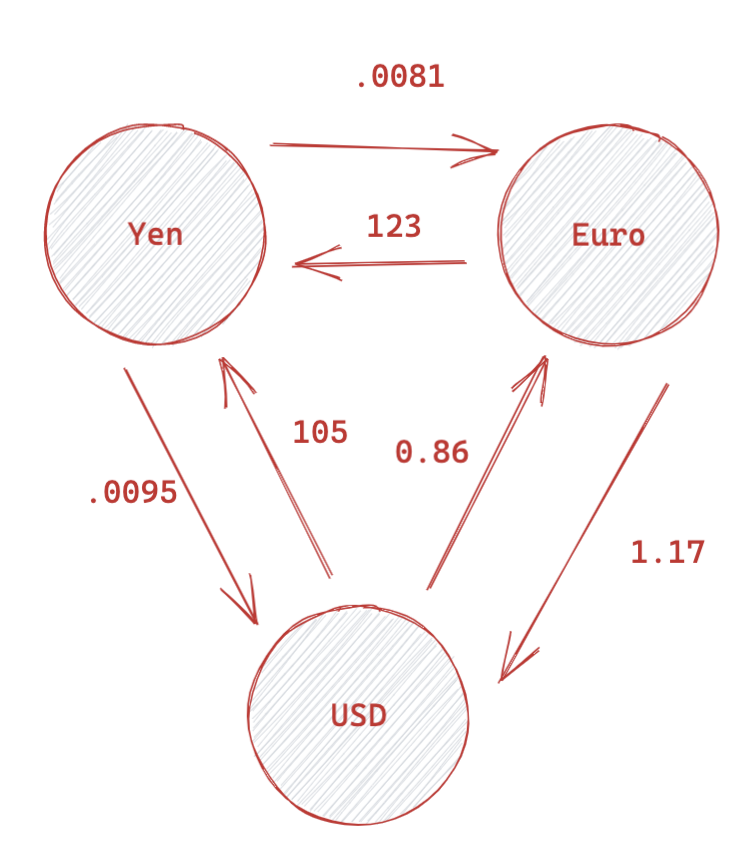

# What can you do on graphs?

- Depth first search
- Breadth first search
- Topological sort
- Find the minimum / maximum path between two (or all) points
- Detect cycles or negative weight cycles
- Find bridges

# How to represent graphs?

Edge list

```
[[0,1], [0,6], [0,8], [1,4], [1,6], [1,9], [2,4], [2,6], [3,4], [3,5],
[3,8], [4,5], [4,9], [7,8], [7,9]]
```

Adjacency matrix

```
[[0, 1, 0, 0, 0, 0, 1, 0, 1, 0],
 [1, 0, 0, 0, 1, 0, 1, 0, 0, 1],
 [0, 0, 0, 0, 1, 0, 1, 0, 0, 0],
 [0, 0, 0, 0, 1, 1, 0, 0, 1, 0],
 [0, 1, 1, 1, 0, 1, 0, 0, 0, 1],
 [0, 0, 0, 1, 1, 0, 0, 0, 0, 0],
 [1, 1, 1, 0, 0, 0, 0, 0, 0, 0],
 [0, 0, 0, 0, 0, 0, 0, 0, 1, 1],
 [1, 0, 0, 1, 0, 0, 0, 1, 0, 0],
 [0, 1, 0, 0, 1, 0, 0, 1, 0, 0]]
```

Adjacency list

```
[[1, 6, 8],
 [0, 4, 6, 9],
 [4, 6],
 [4, 5, 8],
 [1, 2, 3, 5, 9],
 [3, 4],
 [0, 1, 2],
 [8, 9],
 [0, 3, 7],
 [1, 4, 7]]
```

Objects

```
const node1 = {};
const node2 = {};
node1.neighbors = [node2];
node2.neighbors = [node1];
```

Adjacency lists with only one item

```
[1,    // node 0
 3,    //      1
 null, //      2
 2,    //      3
 3]    //      4
```

- We can use these to represent how we got to a node

Now you try it!

- Given such an adjacency list and a starting node, return an array that results from following the items, or false if there is a cycle.
- Recommended: First, assume there is no cycle, then add that functionality
- In the above case, the answer with starting node 0 I want is `[0,1,3,2]`

# Breadth First Search

Breadth-First Search For Trees

- Add the starting node into the first-in-first-out queue
- While the queue is not empty, take an item off of the queue
  - This is called visiting it. Do whatever you need with it.
  - Add all of its children into the queue

What is a queue?

Now you try it!

- Implement breadth first search on a tree. Return true if an item is in the tree, false otherwise.
- `bfsContains(rootNode, valueToFind)` returns a boolean

Trees vs graphs

- Remember trees are **acyclic** graphs where each node has at most one parent
- So, no need to keep track of which nodes are visited
- But what if that’s not true?

Keeping track of visited nodes

- Now, we can’t do pure recursion, because the solution to a sub-problem is not independent
- Instead, keep track of visited nodes in a Set

Our state

```
const queue = [rootNode]
const visited = new Set();
while (queue.length > 0) {
  // do stuff
}
```

Sets in Javascript

```
a = new Set();
a.add(3);
a.has(3);
a.delete(3);
```

Now you try it!

- Implement breadth-first search with a graph
- `bfsGraphContains(rootNode, valueToFind)` returns a boolean

Let’s keep track of how we got somewhere

```
const parents = new Array(n).fill(null);
// whenever we navigate to a node n, set parents[n] = nodeWeJustCameFrom;
// then, we can iterate through this node
```

Now you try it!

- Use BFS to find the shortest path to a particular node

# Djikstra’s algorithm

It’s like BFS, but with positive weights

- Used for finding the shortest path between two nodes
- Instead of using a first-in-first-out queue, use a priority queue

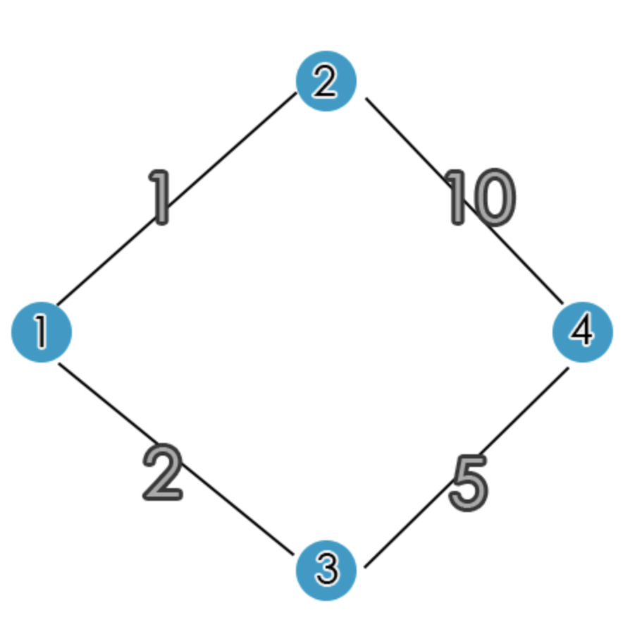

Now you try it!

- Modify the BFS implementation to use a priority queue, where the priority is the weight of the connection

Now you try it!

- Use BFS and a depth limit to find all of the nodes that are visitable in “n” turns from a root node